# Salary Survey

Conor Jayich

2025-05-27

## Intro

This survey data is from www.askamanager.org and focuses on salary income based on age, gender, experience, and industry. The data includes free-form text entry and is therefore messy, and needs cleaning. In this scenario, we are only interested in data from the United States. The objective of this project will be to clean the data, and answer the following questions using RStudio: 1. Which industries pay the most, and which the least? 2. How does work experience correlate to salary?

## Initializing

The first step is getting useful packages…

```r
library(ggplot2)
library(tidyverse)
library(dplyr)
```

and bringing in the data.

```r
survey_data <- read_csv("/home/conor/Downloads/Ask A Manager Salary Survey 2021.csv")
head(survey_data)
```

```
## # A tibble: 6 × 18
##   Timestamp          `How old are you?` What industry do you work …¹ `Job title`
##   <chr>              <chr>              <chr>                        <chr>
## 1 4/27/2021 11:02:10 25-34              Education (Higher Education) Research a…
## 2 4/27/2021 11:02:22 25-34              Computing or Tech            Change & I…
## 3 4/27/2021 11:02:38 25-34              Accounting, Banking & Finan… Marketing …
## 4 4/27/2021 11:02:41 25-34              Nonprofits                   Program Ma…
## 5 4/27/2021 11:02:42 25-34              Accounting, Banking & Finan… Accounting…
## 6 4/27/2021 11:02:46 25-34              Education (Higher Education) Scholarly …
## # ℹ abbreviated name: ¹`What industry do you work in?`
## # ℹ 14 more variables:
## #   `If your job title needs additional context, please clarify here:` <chr>,
## #   `What is your annual salary? (You'll indicate the currency in a later question. If you are part-time or hourly, please enter an annualized equivalent -- what you would earn if you worked the job 40 hours a week, 52 weeks a year.)` <dbl>,
## #   `How much additional monetary compensation do you get, if any (for example, bonuses or overtime in an average year)? Please only include monetary compensation here, not the value of benefits.` <chr>,
## #   `Please indicate the currency` <chr>,
## #   `If "Other," please indicate the currency here:` <chr>, …
```

## Cleaning

Let us start by renaming the column titles to something more useful

```r
survey_data <- survey_data %>%
  rename(
    timestamp = `Timestamp`,
    age_range = `How old are you?`,
    industry = `What industry do you work in?`,
    job_title = `Job title`,
    context_job_title = `If your job title needs additional context, please clarify here:`,
    salary = `What is your annual salary? (You'll indicate the currency in a later question. If you are part-time or hourly, please enter an annualized equivalent -- what you would earn if you worked the job 40 hours a week, 52 weeks a year.)`,
    bonus = `How much additional monetary compensation do you get, if any (for example, bonuses or overtime in an average year)? Please only include monetary compensation here, not the value of benefits.`,
    currency = `Please indicate the currency`,
    currency_other = `If "Other," please indicate the currency here:`,
    context_currency = `If your income needs additional context, please provide it here:`,
    country = `What country do you work in?`,
    state = `If you're in the U.S., what state do you work in?`,
    city = `What city do you work in?`,
    exp_general = `How many years of professional work experience do you have overall?`,
    exp_industry = `How many years of professional work experience do you have in your field?`,
    education = `What is your highest level of education completed?`,
    gender = `What is your gender?`,
    race = `What is your race? (Choose all that apply.)`
  )

head(survey_data)
```

```
## # A tibble: 6 × 18
##   timestamp age_range industry job_title context_job_title salary bonus currency
##   <chr>     <chr>     <chr>    <chr>     <chr>              <dbl> <chr> <chr>
## 1 4/27/202… 25-34     Educati… Research… <NA>               55000 0     USD
## 2 4/27/202… 25-34     Computi… Change &… <NA>               54600 4000  GBP
## 3 4/27/202… 25-34     Account… Marketin… <NA>               34000 <NA>  USD
## 4 4/27/202… 25-34     Nonprof… Program … <NA>               62000 3000  USD
## 5 4/27/202… 25-34     Account… Accounti… <NA>               60000 7000  USD
## 6 4/27/202… 25-34     Educati… Scholarl… <NA>               62000 <NA>  USD
## # ℹ 10 more variables: currency_other <chr>, context_currency <chr>,
## #   country <chr>, state <chr>, city <chr>, exp_general <chr>,
## #   exp_industry <chr>, education <chr>, gender <chr>, race <chr>
```

To clean the currency section up, I have decided I am not interested in keeping the salary and bonuses separate. For this step, I will simply take the sum of salary and bonuses, and work with that annual total.

```r
survey_data <- survey_data %>%
  mutate_at(c('salary','bonus'), as.numeric) %>%
  replace_na(list(salary = 0, bonus = 0)) %>%
  mutate(income_annual = rowSums(select(., salary, bonus)))

head(survey_data)
```

```
## # A tibble: 6 × 19
##   timestamp age_range industry job_title context_job_title salary bonus currency
##   <chr>     <chr>     <chr>    <chr>     <chr>              <dbl> <dbl> <chr>
## 1 4/27/202… 25-34     Educati… Research… <NA>               55000     0 USD
## 2 4/27/202… 25-34     Computi… Change &… <NA>               54600  4000 GBP
## 3 4/27/202… 25-34     Account… Marketin… <NA>               34000     0 USD
## 4 4/27/202… 25-34     Nonprof… Program … <NA>               62000  3000 USD
## 5 4/27/202… 25-34     Account… Accounti… <NA>               60000  7000 USD
## 6 4/27/202… 25-34     Educati… Scholarl… <NA>               62000     0 USD
## # ℹ 11 more variables: currency_other <chr>, context_currency <chr>,
## #   country <chr>, state <chr>, city <chr>, exp_general <chr>,
## #   exp_industry <chr>, education <chr>, gender <chr>, race <chr>,
## #   income_annual <dbl>
```

Now, in the country column, it would be best to replace all variations of ‘US’ or ‘USA’ with ‘United States’ and proceed to filter out all other responses. We do lose some data here in the form of mispellings or people who decided to use the United States Flag Emoji instead of typing.

```r
survey_data <- survey_data %>%
  mutate(country = case_match(
    country, c('america','America,','USA','US','U.S.','U.S','U.S.A','Usa','usa','Us','us') ~ "United States",
    .default = country)
    )

survey_data <- survey_data %>% filter(country == 'United States')

head(survey_data)
```

```
## # A tibble: 6 × 19
##   timestamp age_range industry job_title context_job_title salary bonus currency
##   <chr>     <chr>     <chr>    <chr>     <chr>              <dbl> <dbl> <chr>
## 1 4/27/202… 25-34     Educati… Research… <NA>               55000     0 USD
## 2 4/27/202… 25-34     Account… Marketin… <NA>               34000     0 USD
## 3 4/27/202… 25-34     Nonprof… Program … <NA>               62000  3000 USD
## 4 4/27/202… 25-34     Account… Accounti… <NA>               60000  7000 USD
## 5 4/27/202… 25-34     Educati… Scholarl… <NA>               62000     0 USD
## 6 4/27/202… 25-34     Publish… Publishi… <NA>               33000  2000 USD
## # ℹ 11 more variables: currency_other <chr>, context_currency <chr>,
## #   country <chr>, state <chr>, city <chr>, exp_general <chr>,
## #   exp_industry <chr>, education <chr>, gender <chr>, race <chr>,
## #   income_annual <dbl>
```

Within the industry column, there was an option to choose, “Other:” and fill a custom selection. These entries make up a tiny minority of entries can be removed to make the data clearer, and to filter out user errors.

```r
valid_industries <- data.frame(
  industry = c('Accounting, Banking & Finance',
                      'Administration',
                      'Argiculture or Forestry',
                      'Art & Design',
                      'Biotechnology & Pharma',
                      'Business or Consulting',
                      'Computing or Tech',
                      'Education (Primary/Secondary)',
                      'Education (Higher Education)',
                      'Engineering or Manufacturing',
                      'Entertainment',
                      'Galleries, Libraries, Archives & Museums',
                      'Government & Public Administration',
                      'Government Affairs & Lobbying',
                      'Health Care',
                      'Hospitality & Events',
                      'Insurance',
                      'Law',
                      'Law Enforcement & Security',
                      'Leisure, Sport & Tourism',
                      'Marketing, Advertising & PR',
                      'Media & Digital',
                      'Nonprofits',
                      'Property or Construction',
                      'Recruitment or HR',
                      'Retail',
                      'Sales',
                      'Science',
                      'Social Work',
                      'Transport or Logistics',
                      'Utilities & Telecommunications')
)

survey_data <- survey_data %>%
  inner_join(valid_industries)
head(survey_data)
```

```
## # A tibble: 6 × 19
##   timestamp age_range industry job_title context_job_title salary bonus currency
##   <chr>     <chr>     <chr>    <chr>     <chr>              <dbl> <dbl> <chr>
## 1 4/27/202… 25-34     Educati… Research… <NA>               55000     0 USD
## 2 4/27/202… 25-34     Account… Marketin… <NA>               34000     0 USD
## 3 4/27/202… 25-34     Nonprof… Program … <NA>               62000  3000 USD
## 4 4/27/202… 25-34     Account… Accounti… <NA>               60000  7000 USD
## 5 4/27/202… 25-34     Educati… Scholarl… <NA>               62000     0 USD
## 6 4/27/202… 25-34     Educati… Librarian High school, FT    50000     0 USD
## # ℹ 11 more variables: currency_other <chr>, context_currency <chr>,
## #   country <chr>, state <chr>, city <chr>, exp_general <chr>,
## #   exp_industry <chr>, education <chr>, gender <chr>, race <chr>,
## #   income_annual <dbl>
```

This data is now clean enough to answer our questions.

## Analysis

**1. Which industries pay the most, and which the least?**

```r
industry_salaries <- survey_data %>%
  group_by(industry) %>%
  summarise(
    mean_income = mean(income_annual)
  ) %>% arrange(desc(mean_income))
```

A visualization will be nice here I think.

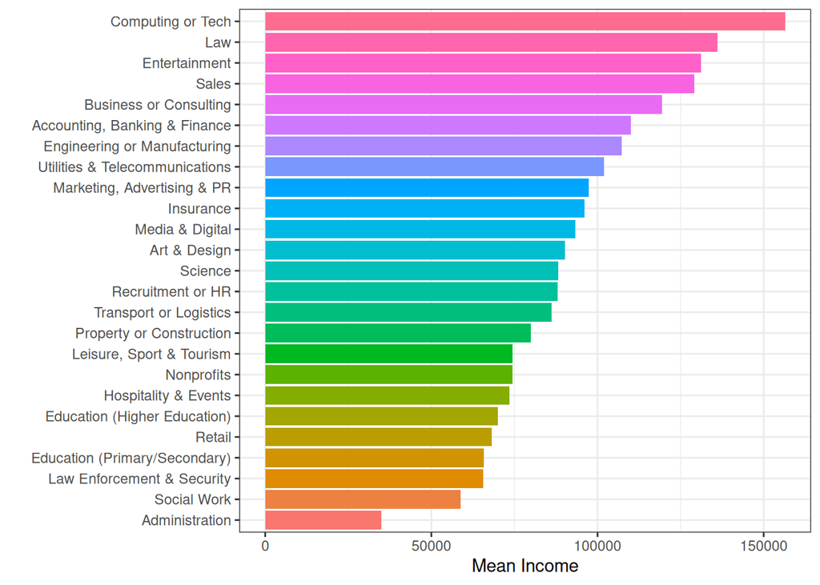

```r
library(forcats)

industry_salaries %>%
  mutate(industry = fct_reorder(industry, mean_income)) %>%
  ggplot(aes(x=industry, y=mean_income, fill = industry)) +
    geom_bar(stat="identity") +
    coord_flip() +
    xlab("") +
    ylab("Mean Income") +
    theme_bw() +
    theme(legend.position = "none")
```

So, according to our cleaned data, the highest earners are in Computing and Tech, Law, and Entertainment. The lowest earning individuals work in Administration, Social Work, and Law Enforcement & Security.

**2. How does work experience correlate to salary?**

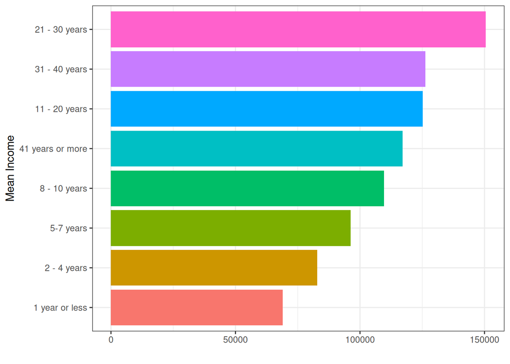

```r
survey_data %>%
  select(income_annual, exp_industry) %>%
  group_by(exp_industry) %>%
  summarise(
    mean_income = mean(income_annual)
  ) %>%
  mutate(exp_industry = fct_reorder(exp_industry, mean_income)) %>%
  ggplot(aes(x = exp_industry, y = mean_income, fill = exp_industry)) +
  geom_bar(stat = "Identity") +
  coord_flip() +
  xlab("Mean Income") +
  ylab("") +
  theme_bw() +
  theme(legend.position = "none")
```

## Conclusion

Here, I took some very messy data, cleaned it, and made some simple observations based on it. This was done using the r libraries, tidyverse, dplyr, and ggplot2. The outcomes were clear, readable, and informative. I effectively took data - much of which was not useful due to input problems - and made it usable for analysis.

However, the method of cleaning used did result in considerable data loss. The data could have been cleaned with a method that minimized data loss at the expense of time. However, this method was beyond the scope of this project.

I took the messy data, made it usable, and answered some basic questions pertaining to its content, and created a basic presentation for it.

Thank you for taking the time to read this :^)